# Mobike 上海数据分析

## by 郑 浩

### 项目综述

在这一次探索过程中，我们通过对摩拜单车2016年8月份上海地区的单车数据进行清洗，梳理，提取出有价值的信息进行分析。从这些分析中我们发现了一些有意思的现象，并为下一步深入分析打下基础。

### 数据集综述

我们在互联网上获取了Mobile 2016年8月份上海地区的运营数据，通过简单的清洗，对数据整理，再利用python的制图类分析工具，对整理后的数据进行分析，得到一些有价值的结论。

```python
# 导入所有需要的模块
import pandas as pd
import numpy as np
import datetime, time
import calendar
import matplotlib.pyplot as plt
import seaborn as sb
import matplotlib.ticker as tick

%matplotlib inline

# suppress warnings from final output
import warnings
warnings.simplefilter("ignore")
```

```python
df = pd.read_csv("2016-Mobike-tripdata-clean.csv")
```

### 人群骑行的使用频率

我们发现这一个月中上海地区骑行人群的使用摩拜单车的频率大约是5次，最多有使用25次的，但频次越多人数越少。

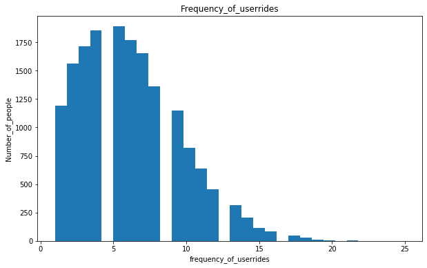

```python
user_rides = df.groupby('userid')['bikeid'].size().reset_index().rename(columns={'bikeid':' frequency_of_userrides'})
plt.figure(figsize=(10,6))
plt.hist(data=user_rides, x=' frequency_of_userrides', bins=30)
plt.xlabel('frequency_of_userrides')
plt.ylabel('Number_of_people')
plt.title('Frequency_of_userrides');
```

### 一周内的骑行特征

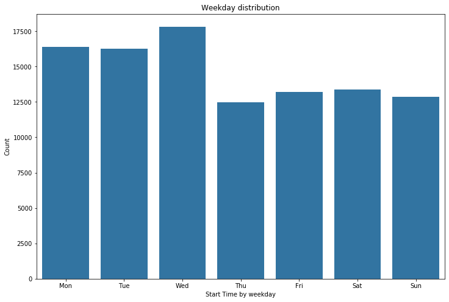

```python
plt.figure(figsize=(12,8))
color1 = sb.color_palette()[0]
sb.countplot(data=df, x='start_weekday_abbr', color=color1, linewidth = 5)
plt.xlabel('Start Time by weekday')
plt.ylabel('Count')
plt.title('Weekday distribution');
```

### 骑行趋势

随着用户和单车投方数量的增加，摩拜单车总的骑行数据呈现上升的趋势

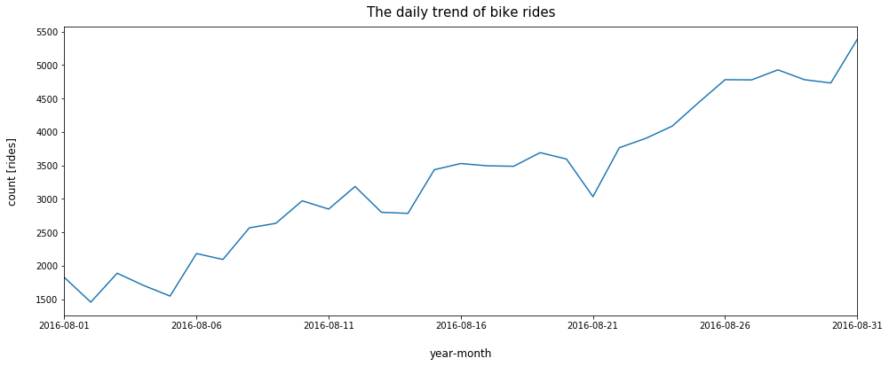

```python
df.groupby('start_time_date').agg({'bikeid':'count'}).plot(style='-', legend=False, figsize=(16,6))
plt.title('The daily trend of bike rides', fontsize=15, y=1.015)
plt.xlabel('year-month', labelpad=20, fontsize=12)
plt.ylabel('count [rides]', labelpad=20, fontsize=12)
```

### 各时段的骑行分布

在一天中的各个时段骑行的数据有所不同，下午时间数量比价多，跟下班的高峰时间有一定关系

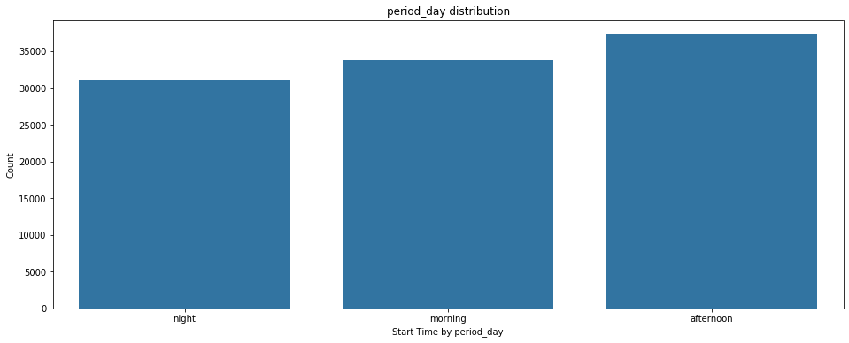

```python
plt.figure(figsize=(16,6))
color2 = sb.color_palette()[1]
sb.countplot(data=df, x='period_day', color=color1, linewidth=5)
plt.xlabel('Start Time by period_day')
plt.ylabel('Count')
plt.title('period_day distribution');
```

### 各时点的数据分布

在一天中的各个时点骑行的数据中，我们发现数据印证了用户的使用场景，基本上都是在早晚高峰出现了骑行数据的高峰，下午时段人的各项活动逐渐活跃，所以骑行量也逐渐提高

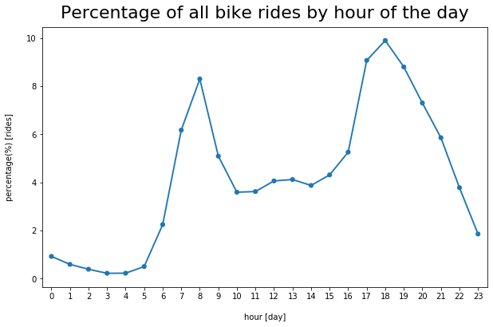

```python
trip_by_weekday_df = df.groupby('start_weekday_abbr').agg({'bikeid':'count'})
trip_by_hour_df = df.groupby('start_time_hour').agg({'bikeid':'count'}).reset_index()
trip_by_hour_df['bikeid'] =(trip_by_hour_df['bikeid']/trip_by_hour_df['bikeid'].sum())*100
plt.figure(figsize=(10,6))
sb.pointplot(x='start_time_hour', y='bikeid', scale=.7, color=color1, data=trip_by_hour_df)
plt.title('Percentage of all bike rides by hour of the day', fontsize=22, y=1.015)
plt.xlabel('hour [day]', labelpad=16)
plt.ylabel('percentage(%) [rides]', labelpad=16)
```

### 骑行时长的分布

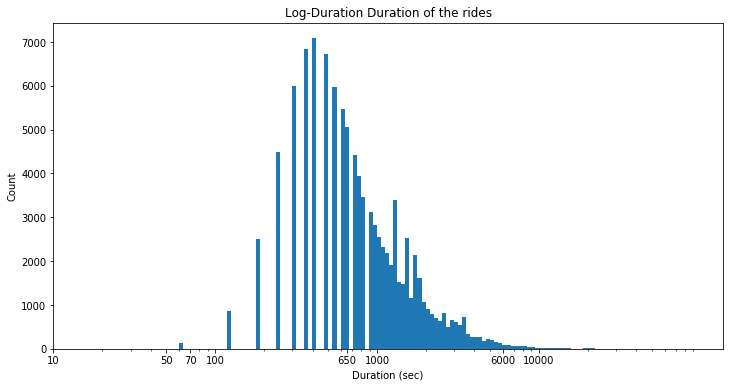

```python
log_binsize = 0.025
bins = 10 ** np.arange(1.2, np.log10(df['duration_sec'].max())+log_binsize, log_binsize)
plt.figure(figsize=[12, 6])
plt.hist(data = df, x = 'duration_sec', bins = bins)
plt.xscale('log')
plt.xticks([10,50,70,100,650,1000,6000,10000], [10,50,70,100,650,1000,6000,10000])
plt.xlabel('Duration (sec)')
plt.ylabel('Count')
plt.title('Log-Duration Duration of the rides');
```

### 各骑行距离的人群有共性

我们对距离信息进行切块，将不同距离的数量分为三类，并查看他们一个月内的变化趋势。我们发现他们的波动趋势十分的相似，并且保持着近似的比例，可以看出影响他们波动的因素来自共同的外部变量。

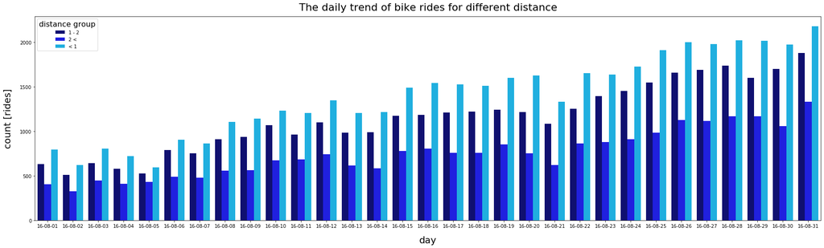

```python
df['distance_km_bins'] = df['distance_km'].apply(lambda x: '< 1' if 0<x<=1
                                                  else '1 - 2' if 1<x<=2
                                                  else '2 <' if 2<x<=96
                                                  else x)
plt.figure(figsize=(30,8))
my_palette = {'< 1': 'deepskyblue', '1 - 2': 'navy', '2 <': 'blue'}
ax = sb.countplot(x='start_time_year_month_day_renamed', hue='distance_km_bins', palette=my_palette, data=df[df['distance_km_bins'].isin(['< 1', '1 - 2', '2 <'])].sort_values(by=['start_time_year_month_day_renamed', 'distance_km_bins']))
plt.title('The daily trend of bike rides for different distance', fontsize=22, y=1.015)
plt.xlabel('day', labelpad=16,fontsize=20)
plt.ylabel('count [rides]', labelpad=16,fontsize=20)
leg = ax.legend()
leg.set_title('distance group',prop={'size':16})
```

### 距离与时间存在相关性

我们对骑行的距离信息和时长信息做了相关性的分析。我们发现这两个变量存在正的相关性，相关系数为0.436,跟人们的直觉一样，距离长自然时间也会越久。我们通过抽样的散点图和直方图也能看出他们近似的线性关系。

[figure not shown]

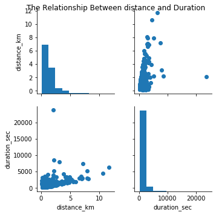

```python
numeric_vars = ['distance_km','duration_sec']
times_chr = ['period_day','start_weekday_char','start_month_char']
samples = np.random.choice(df.shape[0], 500, replace = False)
df_samp = df.loc[samples,:]
plt.figure(figsize=(15,6))
ax = plt.subplot(121)
sb.heatmap(df[numeric_vars].corr(), annot = True, fmt = '.3f',
           cmap = 'Blues', annot_kws={"size": 12},center = 0)
plt.title('Relationship Between distance and Duration');
plt.yticks(rotation=360)

ax = plt.subplot(122)
g = sb.PairGrid(data = df_samp, vars = numeric_vars)
g = g.map_diag(plt.hist, bins = 10)
g.map_offdiag(plt.scatter)
g.fig.suptitle('The Relationship Between distance and Duration');
```

### 短途和上下班场景更多

- 我们发现一个奇怪的现象，小于1公里的骑行人群的用时分布居然跟1-2公里人群的用时分布及其的相似。这两个人群的速度速度是明显的变量，小于1公里的人更多是距离不远也不干时间，1-2公里的人可能需要其更快的速度才能达到目的地。大于2公里的人群的用时明显多于前两群人，可以看出速度是有上线的，要想实现更远的骑行，只能增加时长。
- 我们发现一天中早上时段的人群骑行时间整体来说更短，晚上骑行的人群用时相对更长，可以看出早上由于工作的原因，大家都更敢时间，到了下班甚至晚上人们骑行的时长逐渐增加，更加偏运动或者锻炼。

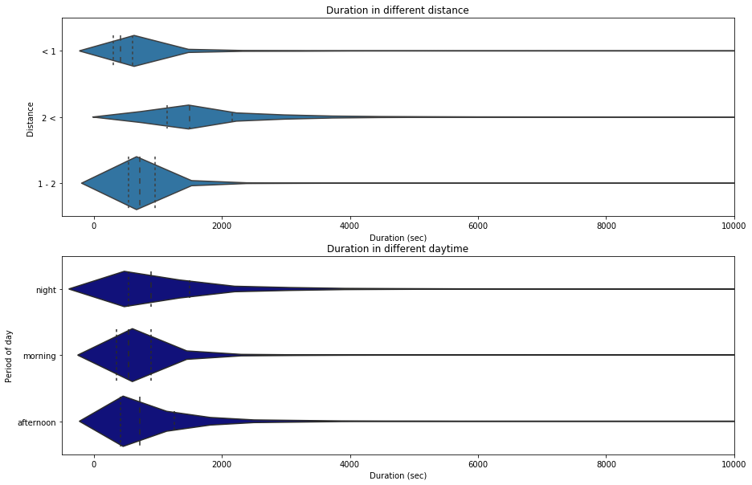

```python
plt.figure(figsize=(15,10))
ax = plt.subplot(211)
sb.violinplot(data=df, y='distance_km_bins', x='duration_sec', inner='quartile', color=color1)
plt.xlim(right = 10000,left = -500)
plt.xlabel('Duration (sec)')
plt.ylabel('Distance')
plt.title('Duration in different distance')

ax = plt.subplot(212)
sb.violinplot(data=df, y='period_day', x='duration_sec', inner='quartile',color='darkblue')
plt.xlim(right = 10000,left = -500)
plt.xlabel('Duration (sec)')
plt.ylabel('Period of day')
plt.title('Duration in different daytime');
```

## 总结

通过此次对摩拜单车数据的探索，我们发现很多用户行为背后的规律，为我们更进一步的挖掘数据价值提供了基础。